# Practical Machine Learning Project

Cris Cunha

10 June 2017

## Introduction

### Background

Using devices such as Jawbone Up, Nike FuelBand, and Fitbit it is now possible to collect a large amount of data about personal activity relatively inexpensively. In this project, we use data from accelerometers on the belt, forearm, arm, and dumbell of 6 participants. Six young health participants were asked to perform one set of 10 repetitions of the Unilateral Dumbbell Biceps Curl in five different fashions: exactly according to the specification (Class A), throwing the elbows to the front (Class B), lifting the dumbbell only halfway (Class C), lowering the dumbbell only halfway (Class D) and throwing the hips to the front (Class E). The goal of this project is to predict the manner in which they did the exercise. This is codified by the “classe” variable contained in the training set.

### Approach

In this project, we developed 2 machine learning models to select the most appropriate classifier to predict the effectiveness of the exercise. These were classification trees and random forest. Model selection was performed based on accuracy in the validation set. From there, the model selected was applied in the testing set to predict the outcomes of the results of the exercises.

## Model selection

In this section we apply the two classifiers to the training set to identify their prediction accuracies and select the best model to be used subsequently in the testing set.

### Setting up the data

Firstly, let’s load the required packages to develop the models

Secondly, we will download the training and testing sets

```r
download.file("https://d396qusza40orc.cloudfront.net/predmachlearn/pml-training.csv",destfile="training.csv")
download.file("https://d396qusza40orc.cloudfront.net/predmachlearn/pml-testing.csv",destfile="testing.csv")
```

We will store the training and test sets into the variables “training” and “testing”

```r
training<-read.csv(("training.csv"),na.strings=c("NA","#DIV/0!",""))
testing<-read.csv(("testing.csv"),na.strings=c("NA","#DIV/0!",""))
```

### Data exploration

We will first explore the training set to understand the configuration of the data set received

```r
dim(training)
```

```
## [1] 19622   160
```

We can see that the training set has 19622 observations accross 160 variables. Next, we will identify what are these variables and their class.

```r
str(training)
```

```
## 'data.frame':    19622 obs. of  160 variables:
##  $ X                       : int  1 2 3 4 5 6 7 8 9 10 ...
##  $ user_name               : Factor w/ 6 levels "adelmo","carlitos",..: 2 2 2 2 2 2 2 2 2 2 ...
##  $ raw_timestamp_part_1    : int  1323084231 1323084231 1323084231 1323084232 1323084232 1323084232 1323084232 1323084232 1323084232 1323084232 ...
##  $ raw_timestamp_part_2    : int  788290 808298 820366 120339 196328 304277 368296 440390 484323 484434 ...
##  $ cvtd_timestamp          : Factor w/ 20 levels "02/12/2011 13:32",..: 9 9 9 9 9 9 9 9 9 9 ...
##  $ new_window              : Factor w/ 2 levels "no","yes": 1 1 1 1 1 1 1 1 1 1 ...
##  $ num_window              : int  11 11 11 12 12 12 12 12 12 12 ...
##  $ roll_belt               : num  1.41 1.41 1.42 1.48 1.48 1.45 1.42 1.42 1.43 1.45 ...
##  $ pitch_belt              : num  8.07 8.07 8.07 8.05 8.07 8.06 8.09 8.13 8.16 8.17 ...
##  $ yaw_belt                : num  -94.4 -94.4 -94.4 -94.4 -94.4 -94.4 -94.4 -94.4 -94.4 -94.4 ...
##  $ total_accel_belt        : int  3 3 3 3 3 3 3 3 3 3 ...
##  $ kurtosis_roll_belt      : num  NA NA NA NA NA NA NA NA NA NA ...
##  $ kurtosis_picth_belt     : num  NA NA NA NA NA NA NA NA NA NA ...
##  $ kurtosis_yaw_belt       : logi  NA NA NA NA NA NA ...
```

[output cut: 86 more lines]

To cross check the testing set, we apply the same exploration.

```r
dim(testing)
```

```
## [1]  20 160
```

```r
str(testing)
```

```
## 'data.frame':    20 obs. of  160 variables:
##  $ X                       : int  1 2 3 4 5 6 7 8 9 10 ...
##  $ user_name               : Factor w/ 6 levels "adelmo","carlitos",..: 6 5 5 1 4 5 5 5 2 3 ...
##  $ raw_timestamp_part_1    : int  1323095002 1322673067 1322673075 1322832789 1322489635 1322673149 1322673128 1322673076 1323084240 1322837822 ...
##  $ raw_timestamp_part_2    : int  868349 778725 342967 560311 814776 510661 766645 54671 916313 384285 ...
##  $ cvtd_timestamp          : Factor w/ 11 levels "02/12/2011 13:33",..: 5 10 10 1 6 11 11 10 3 2 ...
##  $ new_window              : Factor w/ 1 level "no": 1 1 1 1 1 1 1 1 1 1 ...
##  $ num_window              : int  74 431 439 194 235 504 485 440 323 664 ...
##  $ roll_belt               : num  123 1.02 0.87 125 1.35 -5.92 1.2 0.43 0.93 114 ...
##  $ pitch_belt              : num  27 4.87 1.82 -41.6 3.33 1.59 4.44 4.15 6.72 22.4 ...
##  $ yaw_belt                : num  -4.75 -88.9 -88.5 162 -88.6 -87.7 -87.3 -88.5 -93.7 -13.1 ...
##  $ total_accel_belt        : int  20 4 5 17 3 4 4 4 4 18 ...
##  $ kurtosis_roll_belt      : logi  NA NA NA NA NA NA ...
##  $ kurtosis_picth_belt     : logi  NA NA NA NA NA NA ...
##  $ kurtosis_yaw_belt       : logi  NA NA NA NA NA NA ...
```

[output cut: 86 more lines]

The same insights apply to the training set, indicating we can perform a data cleaning step in both sets.

### Data cleaning

Firstly we will remove the variables that present NA observations from both the training and the testing set.

```r
training<-training[,colSums(is.na(training))==0]
testing<-testing[,colSums(is.na(testing))==0]
```

Secondly, let’s exclude the 7 first columns that will not add to the relative information gain for our models from both the training and testing sets.

```r
training<-training[,-c(1:7)]
testing<-testing[,-c(1:7)]
```

We can now see the results of the data cleaning step.

```r
dim(training)
```

```
## [1] 19622    53
```

The training set now has maintained the same number of observations however variables have been reduced from 160 to 53.

```r
dim(testing)
```

```
## [1] 20 53
```

The same applies to the testing set

### Data preparation

We will first put the testing set aside and use cross-validation in the training set to develop our models.

```r
inTrain<-createDataPartition(training$classe,p=0.7,list=FALSE)

training2<-training[inTrain,]
dim(training2)
```

```
## [1] 13737    53
```

The new training set, called “training 2” has 13737 observations accross the 53 variables of the data set.

```r
validation<-training[-inTrain,]
dim(validation)
```

```
## [1] 5885   53
```

The validation set, called “validation” has 5885 observations accross 53 variables.

We will now plot the frequency of each classe variable factor to understand if we have an adequate distribution in the new training set so we don’t face bias problems whilst developing the models.

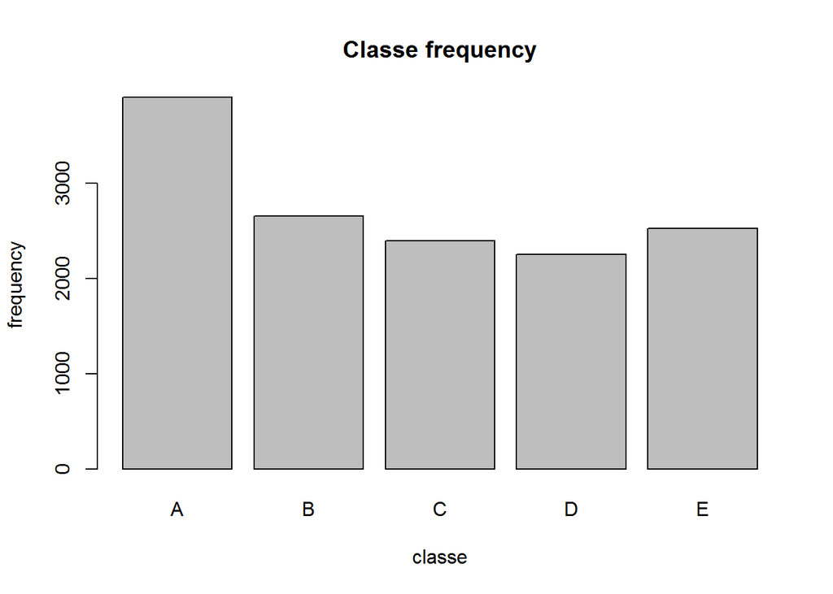

```r
plot(training2$classe,xlab="classe",ylab="frequency",main="Classe frequency")
```

We can see that the factors for the classe variable are well distributed within the same order of magnitude, showing that the training set created is adequate for the model development

### Features discovery and selection

Firstly, let’s set a seed for reproducibility of the results

```r
set.seed(32224)
```

#### Classification tree

The first model will be developed using a classification tree over the training2 set.

```r
modFit<-train(classe~.,method="rpart",data=training2)
modFit$finalModel
```

```
## n= 13737
##
## node), split, n, loss, yval, (yprob)
##       * denotes terminal node
##
##   1) root 13737 9831 A (0.28 0.19 0.17 0.16 0.18)
##     2) roll_belt< 130.5 12602 8703 A (0.31 0.21 0.19 0.18 0.11)
##       4) pitch_forearm< -34.35 1098    5 A (1 0.0046 0 0 0) *
##       5) pitch_forearm>=-34.35 11504 8698 A (0.24 0.23 0.21 0.2 0.12)
##        10) yaw_belt>=169.5 547   52 A (0.9 0.042 0 0.044 0.0091) *
##        11) yaw_belt< 169.5 10957 8327 B (0.21 0.24 0.22 0.2 0.13)
##          22) magnet_dumbbell_z< -93.5 1318  539 A (0.59 0.28 0.052 0.056 0.02) *
##          23) magnet_dumbbell_z>=-93.5 9639 7312 C (0.16 0.23 0.24 0.22 0.14)
##            46) pitch_belt< -42.95 566   88 B (0.014 0.84 0.09 0.023 0.028) *
##            47) pitch_belt>=-42.95 9073 6797 C (0.17 0.2 0.25 0.24 0.15)
##              94) magnet_dumbbell_x>=-447.5 3958 2772 B (0.17 0.3 0.097 0.24 0.19)
##               188) roll_belt< 117.5 2435 1387 B (0.17 0.43 0.023 0.13 0.25) *
##               189) roll_belt>=117.5 1523  896 D (0.19 0.091 0.22 0.41 0.096) *
##              95) magnet_dumbbell_x< -447.5 5115 3224 C (0.16 0.12 0.37 0.23 0.12) *
##     3) roll_belt>=130.5 1135    7 E (0.0062 0 0 0 0.99) *
```

To understand the outcomes of the classification tree, the following plot is performed.

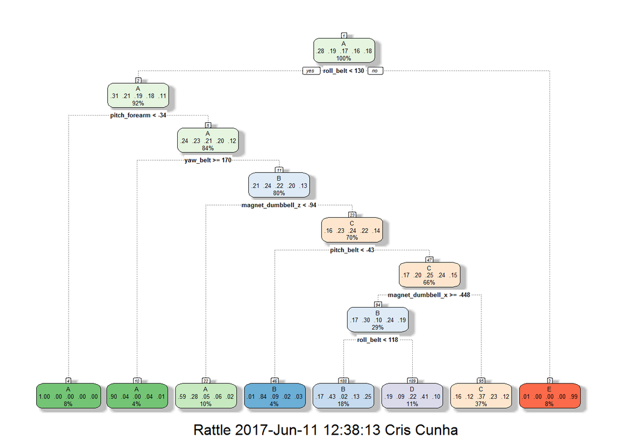

```r
fancyRpartPlot(modFit$finalModel)
```

We can see through the plot that there is a defined pathway for each leaf to each classe variable factor. Let’s now identify the accuracy of this model when predicting on the validation set.

```r
pred<-predict(modFit,validation)
confusionMatrix(pred,validation$classe)
```

```
## Confusion Matrix and Statistics
##
##           Reference
## Prediction    A    B    C    D    E
##          A 1016  177   20   54   19
##          B  178  656   48  135  260
##          C  349  257  820  500  243
##          D  124   49  138  275   57
##          E    7    0    0    0  503
##
## Overall Statistics
##
##                Accuracy : 0.5556
##                  95% CI : (0.5428, 0.5684)
##     No Information Rate : 0.2845
##     P-Value [Acc > NIR] : < 2.2e-16
##
##                   Kappa : 0.443
##  Mcnemar's Test P-Value : < 2.2e-16
##
## Statistics by Class:
##
##                      Class: A Class: B Class: C Class: D Class: E
## Sensitivity            0.6069   0.5759   0.7992  0.28527  0.46488
## Specificity            0.9359   0.8692   0.7224  0.92522  0.99854
## Pos Pred Value         0.7900   0.5137   0.3781  0.42768  0.98627
## Neg Pred Value         0.8569   0.8952   0.9446  0.86856  0.89228
## Prevalence             0.2845   0.1935   0.1743  0.16381  0.18386
## Detection Rate         0.1726   0.1115   0.1393  0.04673  0.08547
## Detection Prevalence   0.2185   0.2170   0.3686  0.10926  0.08666
## Balanced Accuracy      0.7714   0.7225   0.7608  0.60524  0.73171
```

As seen from the confusion matrix above, there seems to be a low level of accuracy from the model to predict on the validation se. Let’s extract the accuracy of the classification tree model

```r
confusionMatrix(pred,validation$classe)$overall[[1]]
```

```
## [1] 0.55565
```

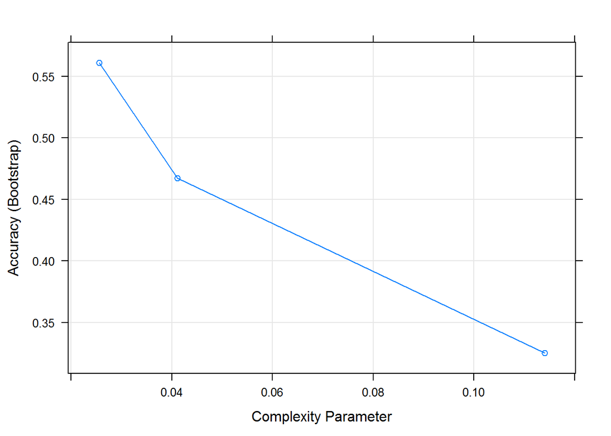

```r
plot(modFit)
```

We can see that the model accuracy reduces sharply as the complexity parameter increases for the bootstrapping resampling used by the classification tree algorithm. This indicates that a model such as random forest, in which uses a stacked majority vote of a number of classification trees might be a good candidate to improve accuracy.

#### Random forest

First, let’s train the training2 data set using a random forest algorithm. Given the computational power required we will allow parallel processing by creating a core cluster to run the model.

```r
modControl <- trainControl(method = "cv",
                           number = 10,
                           allowParallel = TRUE)
```

```r
cluster <- makeCluster(detectCores()- 1)
registerDoParallel(cluster)
```

Let’s now train the model

```r
modFit1<-train(classe~.,method="rf",data=training2, trainControl=modControl)
```

With the model trained, we can stop parallel processing.

```r
stopCluster(cluster)
registerDoSEQ()
```

The results of the model are shown below.

```r
modFit1$finalModel
```

```
##
## Call:
##  randomForest(x = x, y = y, mtry = param$mtry, trainControl = ..1)
##                Type of random forest: classification
##                      Number of trees: 500
## No. of variables tried at each split: 2
##
##         OOB estimate of  error rate: 0.74%
## Confusion matrix:
##      A    B    C    D    E  class.error
## A 3905    1    0    0    0 0.0002560164
## B   18 2636    4    0    0 0.0082768999
## C    0   22 2372    2    0 0.0100166945
## D    2    0   44 2204    2 0.0213143872
## E    0    0    0    6 2519 0.0023762376
```

As it is noted, the confusion matrix shows a much more accurate modelling of the factors in the variable classe. Given the high computational cost of running the random forest algorithm we will save the model and load it as required for future use.

```r
save(modFit1,file="modFit1.RData")
```

```r
load("modFit1.RData")
```

Let’s now use the model to predict on the validation set and identify its performance

```r
pred1<-predict(modFit1,validation)
confusionMatrix(pred1,validation$classe)
```

```
## Confusion Matrix and Statistics
##
##           Reference
## Prediction    A    B    C    D    E
##          A 1673   10    0    0    0
##          B    0 1127    7    0    0
##          C    0    2 1017   10    0
##          D    0    0    2  954    1
##          E    1    0    0    0 1081
##
## Overall Statistics
##
##                Accuracy : 0.9944
##                  95% CI : (0.9921, 0.9961)
##     No Information Rate : 0.2845
##     P-Value [Acc > NIR] : < 2.2e-16
##
##                   Kappa : 0.9929
##  Mcnemar's Test P-Value : NA
##
## Statistics by Class:
##
##                      Class: A Class: B Class: C Class: D Class: E
## Sensitivity            0.9994   0.9895   0.9912   0.9896   0.9991
## Specificity            0.9976   0.9985   0.9975   0.9994   0.9998
## Pos Pred Value         0.9941   0.9938   0.9883   0.9969   0.9991
## Neg Pred Value         0.9998   0.9975   0.9981   0.9980   0.9998
## Prevalence             0.2845   0.1935   0.1743   0.1638   0.1839
## Detection Rate         0.2843   0.1915   0.1728   0.1621   0.1837
## Detection Prevalence   0.2860   0.1927   0.1749   0.1626   0.1839
## Balanced Accuracy      0.9985   0.9940   0.9944   0.9945   0.9994
```

The random forest algorithm performed much better, showing high levels of sensitivity and specificity for all classes in the target variable. The accuracy of the model is:

```r
confusionMatrix(pred1,validation$classe)$overall[[1]]
```

```
## [1] 0.9943925
```

This is a superb improvement from the classification tree algorithm used.

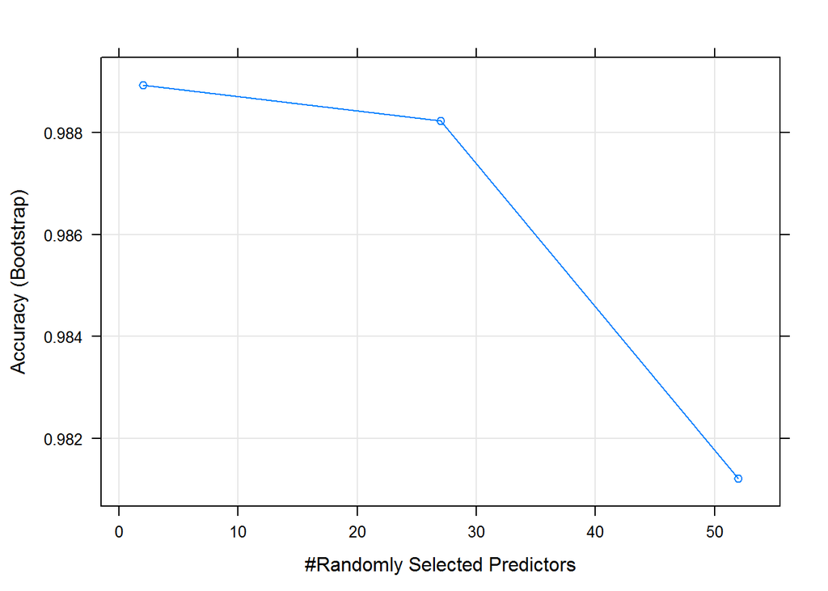

```r
plot(modFit1)
```

## Testing the model

With the random forest model developed, let’s apply to the testing set and see the results

```r
predF<-predict(modFit1,testing)
print(predF)
```

```
##  [1] B A B A A E D B A A B C B A E E A B B B
## Levels: A B C D E
```

The 20 results above are the classe predictions against each one of the 20 observations of the testing set.